# D20 Diameter Method Test

Courtney Meier

2020-12-02

### Stem Diameter method evaluation

A subset of large Ohi’a trees at the NEON D20 PUUM site are supported by large prop roots, creating a bole that becomes regular far higher than 130 cm above the ground. To determine whether a pole-based tape-wrapping technique or calipers might be suitable for reaching measurement locations that cannot be reached from the ground with a standard DBH tape approach, staff collected stem diameter data from a sample of trees (n=20) that could be reached from the ground using three techniques:

- Standard DBH tape (control)
- DBH tape + pole
- Calipers

Here, we use two paired t-tests to determine whether the pole-based method and the caliper method are significantly different from the DBH tape control method.

Summary of input data:

| method | count | mean | stdev |
| --- | --- | --- | --- |
| caliper | 20 | 16.375 | 5.796085 |
| dbhTape | 20 | 16.425 | 5.684779 |
| pole | 20 | 16.385 | 5.687037 |

#### Compare Stem Diameter: Tape control vs. Pole method

```
##
##  Paired t-test
##
## data:  dbhTape and pole
## t = 0.59663, df = 19, p-value = 0.5578
## alternative hypothesis: true difference in means is not equal to 0
## 95 percent confidence interval:
##  -0.1003222  0.1803222
## sample estimates:
## mean of the differences
##                    0.04
```

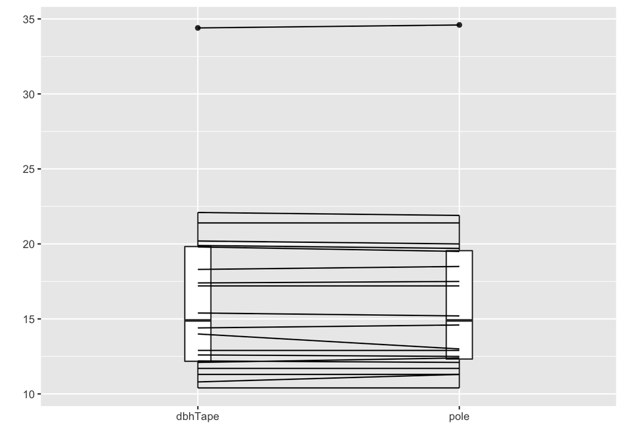

#### Compare Stem Diameter: Tape control vs. Caliper method

```
##
##  Paired t-test
##
## data:  dbhTape and caliper
## t = 0.3746, df = 19, p-value = 0.7121
## alternative hypothesis: true difference in means is not equal to 0
## 95 percent confidence interval:
##  -0.2293681  0.3293681
## sample estimates:
## mean of the differences
##                    0.05
```

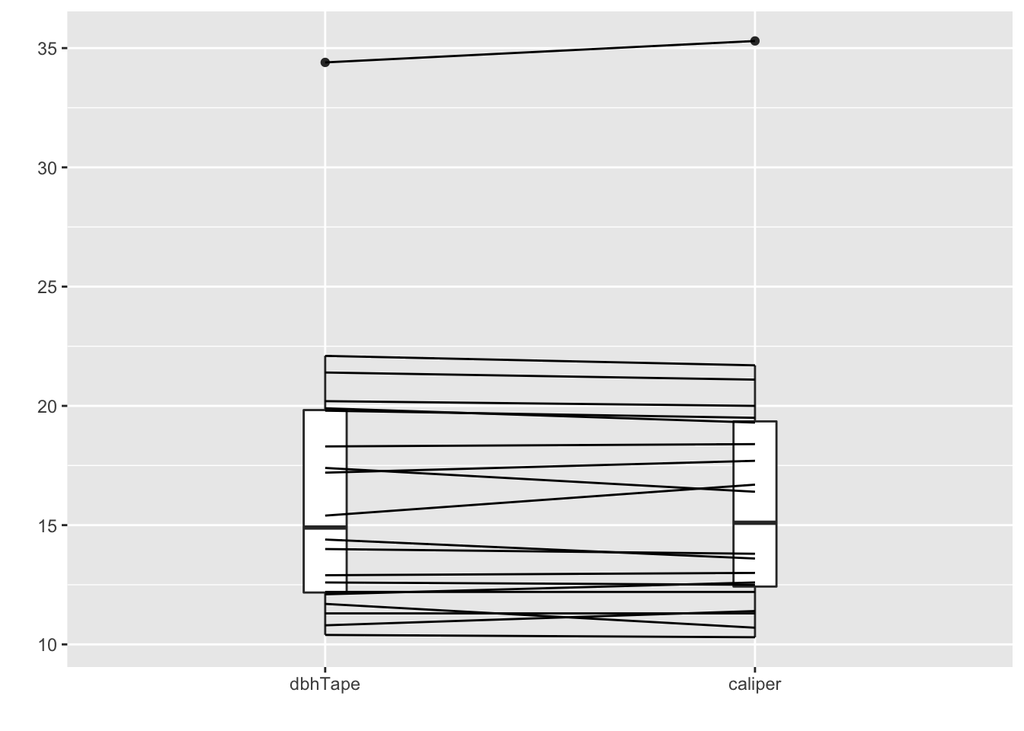

#### Conclusions

- Pole-wrapping method is suitable for large Ohi’a trees when it is not possible to reach the desired measurement location from the ground.
- The caliper method may be suitable for difficult individuals that cannot be safely measured from the ground due to terrain, but the caliper method is not preferred.
- It may be possible to improve the caliper method by making multiple diameter measurements - e.g., two measurements orthogonal to each other. Here, only one diameter measurement was collected with the calipers.